# Recession Indicators

## Auto sales

A WSJ article suggested that auto sales might be a good indicator so bring that to the mix. It does have troughs that correlate with recessions

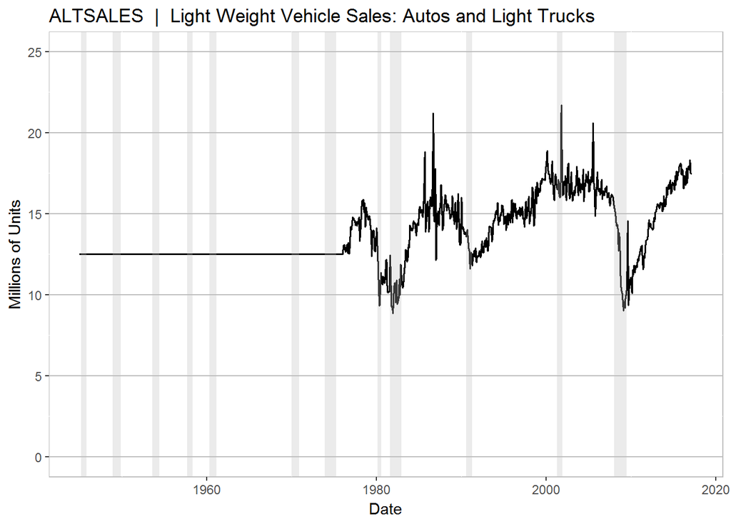

There might be some seasonal variance in the auto sales so lets take a look at the year over year. The data is pretty noisy, it probably will not make a very good indicator.

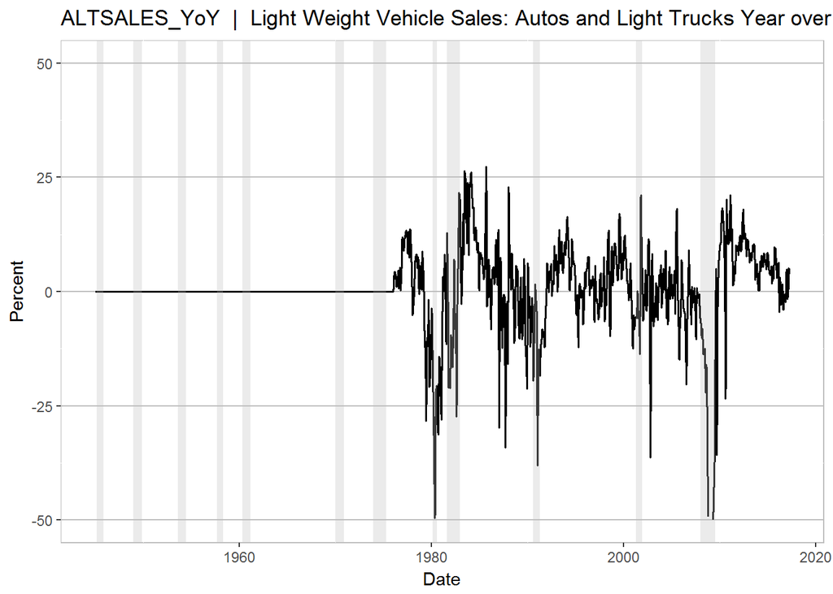

## Gross Domestic Product

GDP numbers tend to lag so this series is truly an afterthought. But it does have some correlation with the recessions.

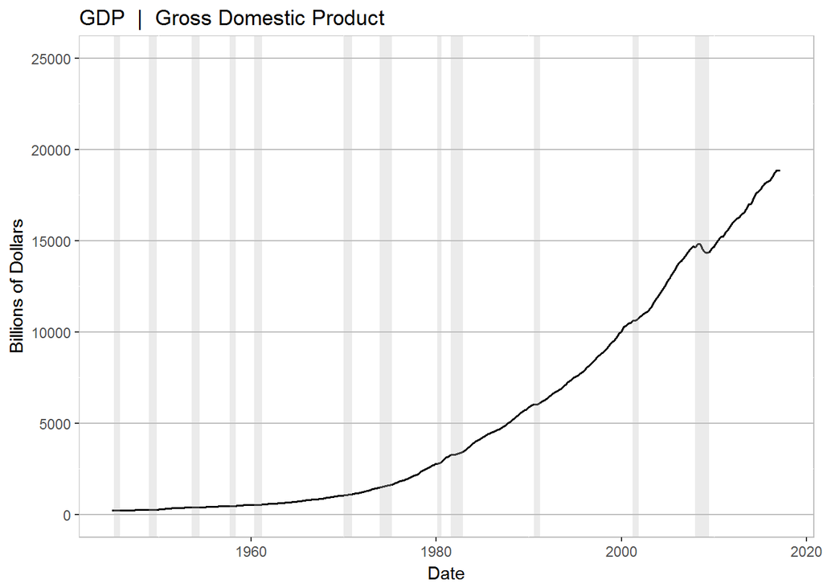

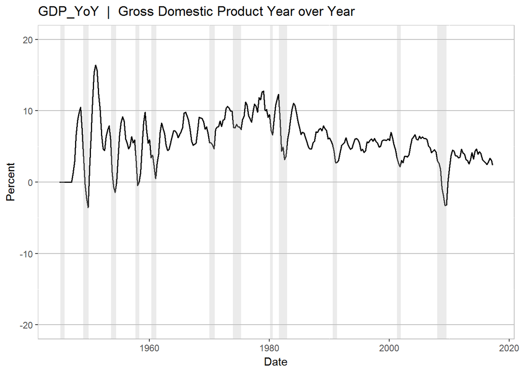

## Correlation Study

Let’s see where we are so far. The correlation plot confirms some of the speculation above. The S&P 500 (GSPC.Open) is well correlated with industrial production (INDPRO), business loans (BUSLOANS), total loans (TOTLNNSA) , and nonfinancial corporate business debt (NCBDBIQ027S).

In this case, I want and indicator that rises prior to a recession. It looks like the unemployment rate (UNRATE), real personal income (W875RX1A020NBEA), and the yield curve (DGS10TO1) are all inversely correlated with the recession initiation indicator.

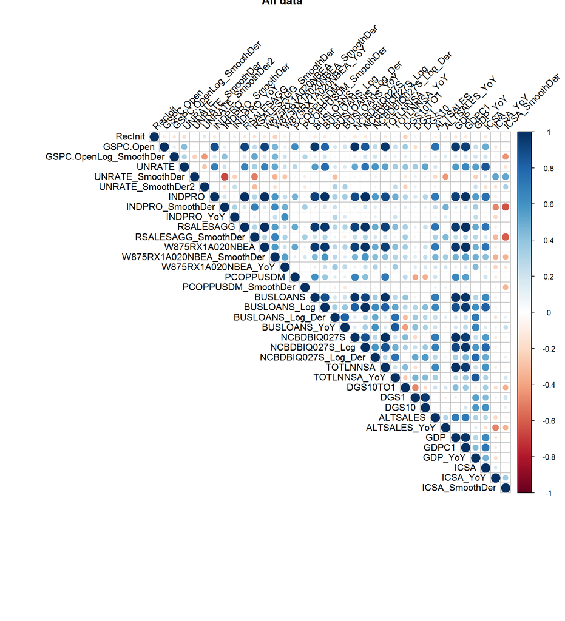

```r
# Correlation for the entire data set
  training.cor <- dfData[,c("RecInit","GSPC.Open","GSPC.OpenLog_SmoothDer",
                            "UNRATE","UNRATE_SmoothDer","UNRATE_SmoothDer2",
                            "INDPRO","INDPRO_SmoothDer","INDPRO_YoY",
                            "RSALESAGG","RSALESAGG_SmoothDer",
                            "W875RX1A020NBEA","W875RX1A020NBEA_SmoothDer","W875RX1A020NBEA_YoY",
                            "PCOPPUSDM", "PCOPPUSDM_SmoothDer",
                            "BUSLOANS","BUSLOANS_Log","BUSLOANS_Log_Der","BUSLOANS_YoY",
                            "NCBDBIQ027S", "NCBDBIQ027S_Log","NCBDBIQ027S_Log_Der",
                            "TOTLNNSA","TOTLNNSA_YoY","DGS10TO1", "DGS1", "DGS10",
                            "ALTSALES","ALTSALES_YoY","GDP", "GDPC1", "GDP_YoY",
                            "ICSA","ICSA_YoY", "ICSA_SmoothDer")]
  rcorr.data <- rcorr(as.matrix(training.cor), type = "pearson")
  #print(rcorr.data)

  corrplot(cor(training.cor), type="upper", order="original",
           tl.col="black", tl.srt=45, title ="All data")
```

I thought the modified recession initiation would be a harder match, but there are quite a few correlated variables.

[figure not shown]

```r
# Correlation for the entire data set
  training.cor <- dfData[,c("RecInit","GSPC.Open","GSPC.OpenLog_SmoothDer",
                            "UNRATE","UNRATE_SmoothDer","UNRATE_SmoothDer2",
                            "INDPRO","INDPRO_SmoothDer","INDPRO_YoY",
                            "RSALESAGG","RSALESAGG_SmoothDer",
                            "W875RX1A020NBEA","W875RX1A020NBEA_SmoothDer","W875RX1A020NBEA_YoY",
                            "PCOPPUSDM", "PCOPPUSDM_SmoothDer",
                            "BUSLOANS","BUSLOANS_Log","BUSLOANS_Log_Der","BUSLOANS_YoY",
                            "NCBDBIQ027S", "NCBDBIQ027S_Log","NCBDBIQ027S_Log_Der",
                            "TOTLNNSA","TOTLNNSA_YoY","DGS10TO1", "DGS1", "DGS10",
                            "ALTSALES","ALTSALES_YoY","GDP", "GDPC1", "GDP_YoY",
                            "ICSA","ICSA_YoY", "ICSA_SmoothDer")]
  rcorr.data <- rcorr(as.matrix(training.cor), type = "pearson")
  #print(rcorr.data)

  corrplot(cor(training.cor), type="upper", order="original",
           tl.col="black", tl.srt=45, title ="All data")
```

# Machine Learning

## Select date range for testing

The data series have different start dates and they are not updated at the same time. This bit of code selects a valid data range to develop the model.

```r
mdlFeat <- c("UNRATE", "W875RX1A020NBEA")

dtStart <- index(get(mdlFeat[1])[1]);
for (strSeries in mdlFeat){
  dtThis <- index(get(strSeries)[1])
  if( dtThis > dtStart){
    dtStart <- dtThis
  }
}

dtEnd <- as.Date("2017-01-01")
dfDataModel <- dfData[dfData$date >= dtStart & dfData$date <= dtEnd,]
```

## Partition the data

I break the data into three sets: 50% for training, 25% for testing, and 25% for validation.

```r
set.seed(123456)
inTrain <- createDataPartition(y=dfDataModel$RecInit, p = 0.50, list=FALSE)
dfTrain <- dfDataModel[inTrain,]
dfData.rest <- dfDataModel[-inTrain,]
inVal <- createDataPartition(y = dfData.rest$RecInit, p = 0.50, list = FALSE)
dfVal <- dfData.rest[inVal,]
dfTest <- dfData.rest[-inVal,]
```

## Create the model

In R, this is the easiest part. I favor simple models because they tend to be more robust. From the data exploration I know that the yield curve is variable with respect to recessions and my recession initiation indicator. I am going to start with the unemployment rate and personal income and see how the model performs.

```r
strEqnPart <- paste("RecInit ~ ", paste(mdlFeat, collapse = "+", sep=""))
modFit <- rpart( strEqnPart, data=dfTrain)
```

The plot below summarizes the correlations in a graphical format. The tree itself is a little more complicated than I like.

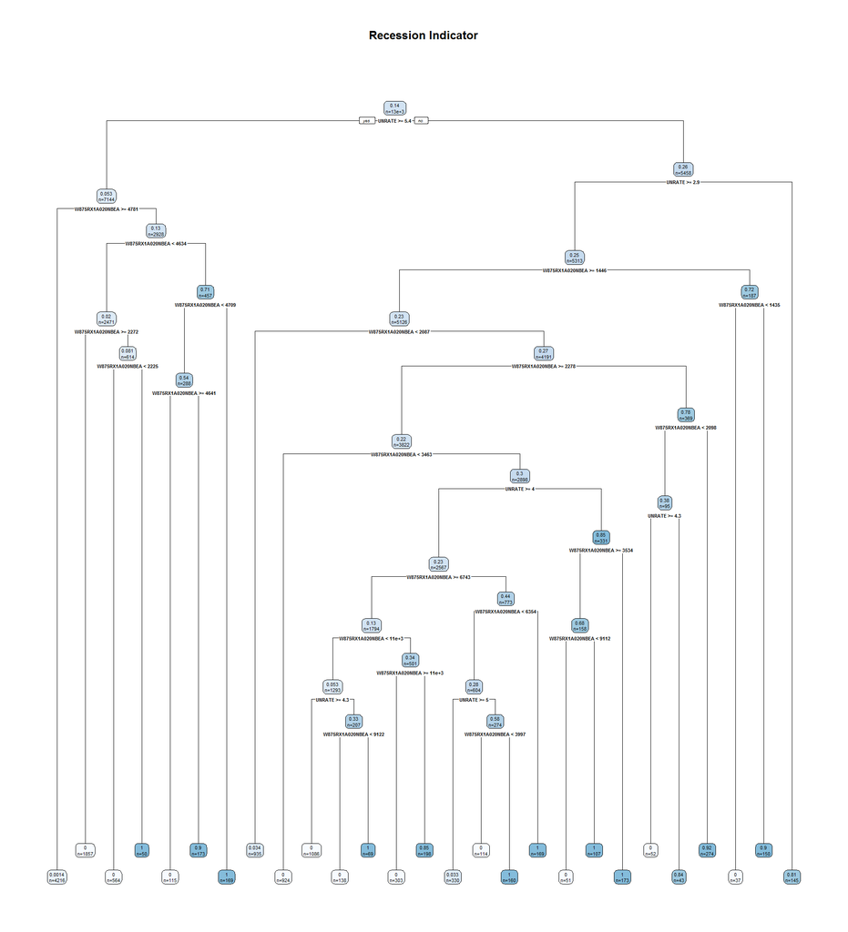

```r
rpart.plot(modFit, main="Recession Indicator", type = 2, extra = 1)
```

## Validation

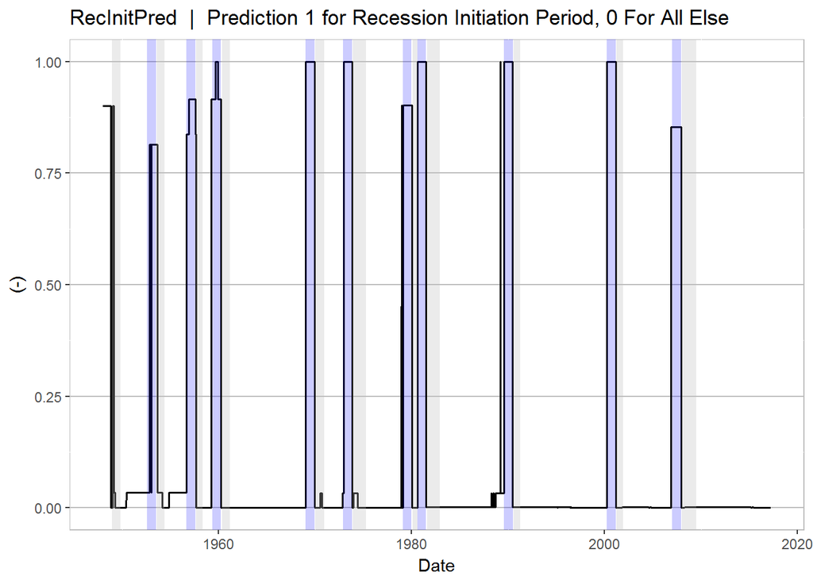

```r
dfData$RecInitPred <- predict(modFit, newdata=dfData)
dfSyms <- rbind(dfSyms, data.frame(Symbol="RecInitPred", Source="Calc",
              Desc="Prediction 1 for Recession Initiation Period, 0 For All Else",
              yLabel ="(-)" ) )


datay <- "RecInitPred"
datay_aux<- "RecInit"
ylim <- c(0, 1)
myPlot <- plotSingleQuickDate(datay, ylim, dtStart)
myPlot + geom_rect(data=dfRecession,  aes(xmin=initStart, xmax=initEnd, ymin=-Inf, ymax=Inf),
              fill="blue", alpha=0.2, na.rm = TRUE)
```

# Creating the Trading Rules

The strategy here will be to go long when the recesion initiation signal is below 0.5. When it crosses 0.5 I will exit the market. I need a signal that will tell me when to get back in. From the data exploration section I noted that the second derivative of the unemployment rate crosses zero right in the middle of most recessions That zero crossing will serve as the buy signal to get back in the market.

## Create the trade rule for recession initiation

```r
# Round off the prediction
dfData$RecInitPredRd <- round(dfData$RecInitPred, digits = 0)
dfSyms <- rbind(dfSyms, data.frame(Symbol="RecInitPredRd", Source="Calc",
              Desc="Rounded Prediction 1 for Recession Initiation\n Period, 0 For All Else",
              yLabel ="(-)" ) )

# Extract the dates from the prediction
dtStartPred <- dfData$date[which(diff(dfData$RecInitPredRd)==1)+1]
dtStartPred <- dtStartPred+30
dtEndPred <- dfData$date[which(diff(dfData$RecInitPredRd)==-1)]

# Zero crossings of the 2nd derivative of the unemployment rate
dZeroUNRATE <- diff(sign(dfData$UNRATE_SmoothDer2))
dZeroUNRATE <- append(dZeroUNRATE, tail(dZeroUNRATE,1))
dfData$dZeroUNRATE <- dZeroUNRATE

# keep only the negative slopes and get rid of any dates
# while the indicator is high
dfData$dZeroUNRATE[dfData$dZeroUNRATE>0] <- 0
dfData$dZeroUNRATE <- -1 * (dfData$dZeroUNRATE * (dfData$RecInitPredRd - 1))


# Find the first negative slope after the recession indicator triggers
dtEndCand <- dfData$date[which(dfData$dZeroUNRATE<0)]
dtBuyPred <- dtStartPred
for (idx in 1:length(dtStartPred)){
  dtBuyPred[idx] <- dtEndCand[min(which(dtEndCand > dtEndPred[idx]))]
}
dfPred <- data.frame(predStart = dtStartPred, predEnd = dtBuyPred)

# Create the trade rule, 1 is long, 0 is not invested
dfData$RecInitTrade <- rep(1, nrow(dfData))

for( idx in 1:nrow(dfPred)){
  dfData$RecInitTrade[which(dfData$date>dfPred$predStart[idx] & dfData$date<dfPred$predEnd[idx])]=0
}
dfSyms <- rbind(dfSyms, data.frame(Symbol="RecInitTrade", Source="Calc",
              Desc="Recession Initiation Trade Rule",
              yLabel ="(-)" ) )
```

## Plot the Backtesting Results

### Create the Baseline Data Series

The trading strategy will be compared to the S&P 500, shown below. We use this to create an S&P 500 rate of change series. The trading rule will move in and out of this series.

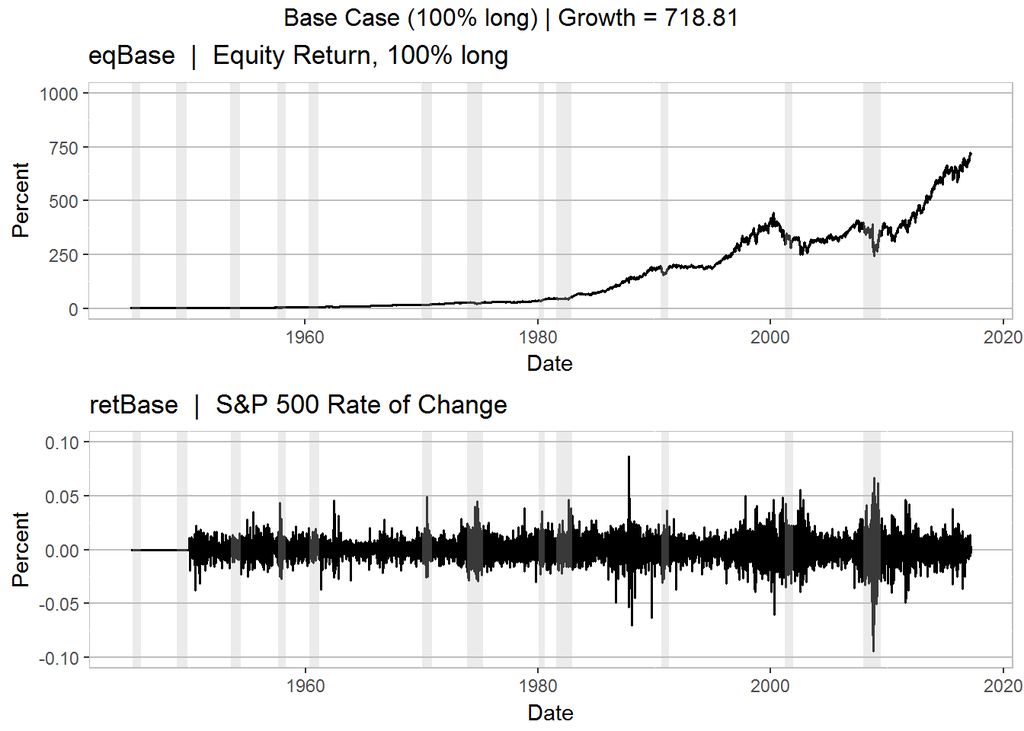

```r
dfData$retBase <- ROC(dfData$GSPC.Close)
dfData$retBase[is.na(dfData$retBase)] <- 0
dfSyms <- rbind(dfSyms, data.frame(Symbol="retBase", Source="Calc",
              Desc="S&P 500 Rate of Change",
              yLabel ="Percent" ) )

dfData$eqBase <- exp(cumsum(dfData$retBase))
dfSyms <- rbind(dfSyms, data.frame(Symbol="eqBase", Source="Calc",
              Desc="Equity Return, 100% long",
              yLabel ="Percent" ) )

datay <- "eqBase"
ylim <- c(0, 1000)
p1 <- plotSingleQuick(datay, ylim)

datay <- "retBase"
ylim <- c(-0.1, 0.1)
p2 <- plotSingleQuick(datay, ylim)

grid.arrange(p1, p2, ncol = 1, top = paste("Base Case (100% long) | Growth = ", sprintf('%0.2f', tail(dfData$eqBase,1)), sep=""))
```

### Perform the Backtesting and Plot the Results

In this final analysis step the trading rule is plotted along with the indicator in the top pane. The middle pane shows how the trading rule modified the rate of change series. The bottom plots shows how the investment performed, compared to the S&P 500.

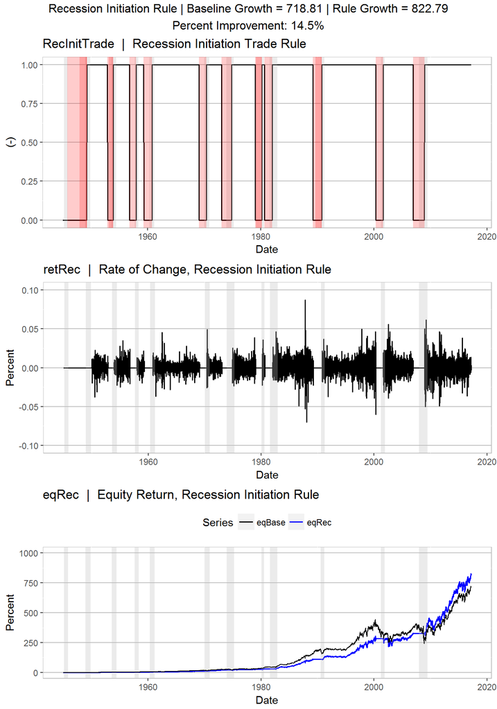

```r
dfData$retRec <- dfData$retBase * dfData$RecInitTrade
dfSyms <- rbind(dfSyms, data.frame(Symbol="retRec", Source="Calc",
              Desc="Rate of Change, Recession Initiation Rule",
              yLabel ="Percent" ) )

dfData$eqRec <- exp(cumsum(dfData$retRec))
dfSyms <- rbind(dfSyms, data.frame(Symbol="eqRec", Source="Calc",
              Desc="Equity Return, Recession Initiation Rule",
              yLabel ="Percent" ) )

dataTrade <- "RecInitTrade"
dataRet <- "retRec"
dataEq <- "eqRec"
p1 <- plotBack(dataTrade, dataRet, dataEq, dfPred)
```

The trading strategy resulted in an improved return, although most of this comes after the 2007-2008 recession. In that recession the trading rules return to the long position at the exact market bottom. This is in contrast to the 1999-2000 recession where the trading rule returns to long before the market bottoms.

# Conclusion

In this worksheet a model predicting the onset of recession was built. From the model a trading rule was derived to allow backtesting. The model performed well and the trading rule backtesting showed that applying this in the post-WWII period would have resulted in a 14.5% increase in returns. That is not too bad, but there are a few changes that would likely improve the model:

- Go long on short term bonds, rather than just roll out of the market. That way at least some returns would be generated during recessions.
- Refine the recession indicator. The square shape of the indicator makes it difficult to model. Something more like a windowed sync function might give better results.

As it is the model does provide value. It will be interesting to see how it hold up over the next few years.